# Calcul statistique sur les composantes magnétiques avec le package ArMag

## Plot the schmitt-Lambert projection

Each function using different parameters

```r
lambert.XYZ.specimen(mes.ech)
# remove anisotropîe step
mes.ech.ssAni<-remove.step(mes.ech)
```

```
#> [1] "550Z+" "550Z-" "550X+" "550X-" "550Y+" "550Y-" "550ZB"
```

[figure not shown]

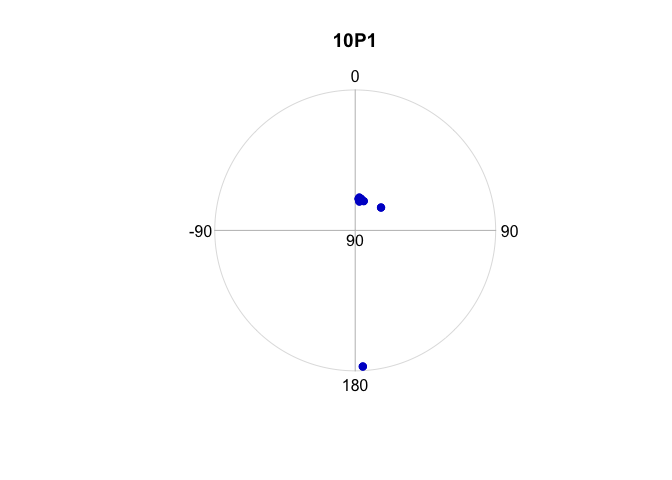

```r
lambert.ID.specimen(mes.ech.ssAni)
```

## demagnetizing and partial component

```r
mes.sel2 <- extract.mesures.specimen.name("1P1", mes)
mes.sel3 <- extract.mesures.specimen.name("16P1", mes)
demag(mes.sel2, step.J0 = NULL)
demag(mes, step.J0 = 0, pt.col = rainbow(length(mes.info$name)))
demag(rbind(mes.sel2, mes.sel3), normalize = TRUE)

partial.component(mes.sel2$X, mes.sel2$Y, mes.sel2$Z)
```

```
#>           X           Y         Z        I         D F         Sl      MAD
#> 1 0.2726137 -0.02949615 0.9616713 74.08537 -6.175245 1 0.03145648 34.52748
#>        DANG
#> 1 0.5730495
```

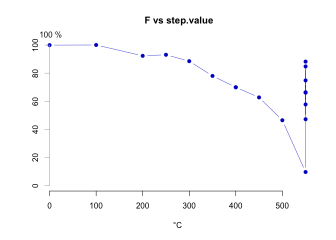

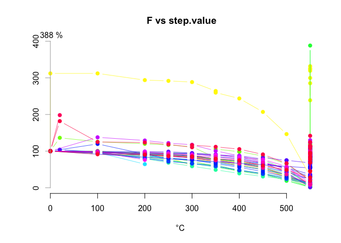

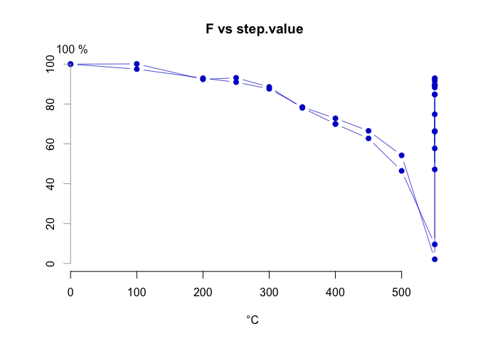

## Synthetic view of a sample

The zijderveld1.T1T2 and zijderveld2.T1T2 functions remove the anisotropy steps by default

```r
par(mfrow = c(2, 2), cex.lab = 0.7, cex.axis = .7, cex = 0.7, cex.main = 1, cex.sub = 0.1,
    mai = c(0.5, 0.5, 0.7, 0.3), oma = c(0, 1, 1, 1))#, pty ="s" )
zijderveld1.T1T2(mes.sel2)
```

```
#> [1] "550Z+" "550Z-" "550X+" "550X-" "550Y+" "550Y-" "550ZB"
```

```r
zijderveld2.T1T2(mes.sel2)
```

```
#> [1] "550Z+" "550Z-" "550X+" "550X-" "550Y+" "550Y-" "550ZB"
```

```r
# removal of anisotropy steps
mes.sel2 <- remove.step(mes.sel2, verbose = FALSE)
lambert(mes.sel2, inc.lim = c(0, 90))
demag(mes.sel2, step.J0 = NULL)
```

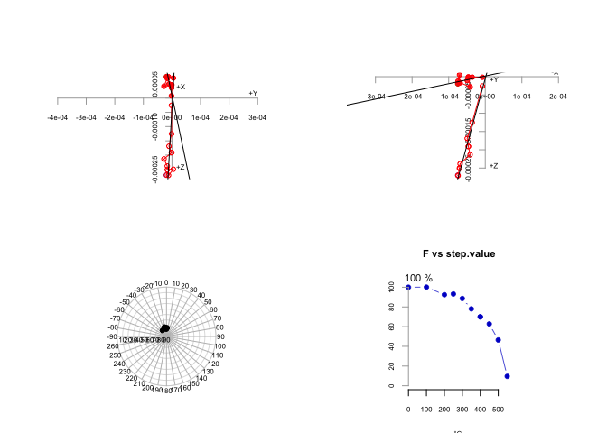

Synthetic view

## Arai - intensity plot

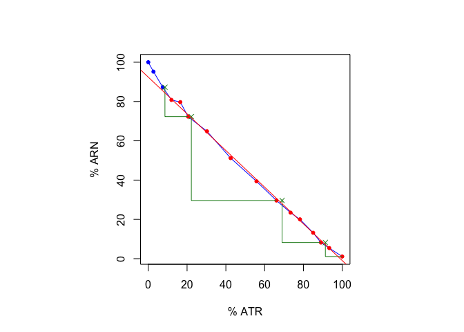

```
#> [1] "Coef. Corr. lin. R= -0.999 pour 13 points"
#> [2] " Sigmab ( Coe 1978) = 0.0123"
#> [3] "with lab field : 60 µT => Fe= 56 ± 0.737 µT (Coe et Al. 1978)"
#> [4] "f = 87.62% (Coe et Al. 1978)"
#> [5] "q = 59.9"
#> [6] "g  = 0.899"
#> [7] "Crm  = 7.216e-11 (Coe 1984)"
#> [8] "q (Prévost 85) = 64.1"
#> [9] "sigma (Prévost 85) = 0.0131"
#> [1] "Speed Rate with slow step: -0.6727 %"
#> [2] "Derive speed Rate with quick step: -0.1607 %"
#> [3] "Fe Lent= 56.4 ± 0.742 µT"
#> $ARN
#>                X             Y             Z         I        D            F
#> 1  -3.226852e-10 -1.258333e-09 -1.208333e-09 -42.92797 255.6171 1.774147e-09
```

[output cut: 88 more lines]

```r
file.INT <- "../examples/INT_example.AMD"

mesINT <- NULL
mesINT <- read.AM.mesures(file.INT)
mesINT.info <- read.AM.info (file.INT)
mes.sel<- extract.mesures.specimen.name("40001B_11B1", mesINT)
# reference
# Coe 1978 : DOI: 10.1029/JB083iB04p01740
# Prévost et Al. 1985 DOI: 10.1029/JB090iB12p10417
par(pty="s", "xaxp")
relative = FALSE
verbose = TRUE
show.plot = TRUE
vol=10.8
TH = 60
aim.coef = 1E-10*1E6/vol #1E6
show.step.value = FALSE
R.mark = 'R'  # Positive pTRM
V.mark = 'V'  # Negative pTRM
P.mark = 'P'  # pTRM check
L.mark = "L"  # sLow cooling
Q.mark = "Q"  # Quick cooling
pt.col = "blue"
loop.col = "forestgreen"
step.J0 = "20N0" # ou NULL

begin.step.value = 0
end.step.value = 700

par(pty="s", "xaxp")
arai(mes.sel, begin.step.value = 250, end.step.value = 700, aim.coef = 1E-10*1E6/vol)
```

# Sun azimuth

```r
sun.azimuth (10, 11, 2019, 11, 19, seconde=0, 48, longmin=0, longsec=0, 45, latmin=0, latsec=0)
```

```
#> [1] 221.8943
```

# igrf13syn

This is a synthesis routine for the 13th generation [IGRF](https://www.ngdc.noaa.gov/IAGA/vmod/igrf.html) as agreed in December 2019 by IAGA Working Group V-MOD. It is valid 1900.0 to 2025.0 inclusive. Values for dates from 1945.0 to 2015.0 inclusive are definitive, otherwise they are non-definitive. Reference:

[Thébault, E., Finlay, C.C., Beggan, C.D. et al. International Geomagnetic Reference Field: the 12th generation. Earth Planet Sp 67, 79 (2015). https://doi.org/10.1186/s40623-015-0228-9](https://earth-planets-space.springeropen.com/articles/10.1186/s40623-015-0228-9)

```r
isv <- 1
date <- 2000
itype <- 1
alt <- 50
colat <- 90 - 45
elong <- 10

igrf13syn(isv=isv, date=date, itype=itype , alt=alt, colat= colat, elong=elong)
```

```
#> $x
#> [1] 8.357313
#>
#> $y
#> [1] 37.63232
#>
#> $z
#> [1] 31.11141
#>
#> $f
#> [1] 49.53742
#>
#> $type
#> [1] "Secular Variation"
#>
#> $dec
#> [1] 77.47906
#>
#> $inc
#> [1] 38.90556
#>
#> $hoz
#> [1] 38.54914
```